# Week-1-day-3-Data Auditing and Missingness Mechanism

[figure not shown]

## **Missing Data Mechanisms & Imputation Strategies in MOH Records**

### **Handling Missing Clinical & Lab Data (MCAR, MAR, MNAR)**

### **Load the Required Libraries**

```python
import pandas as pd
import numpy as np
import matplotlib.pyplot as plt
import seaborn as sns
from scipy import stats
import warnings

# Scikit-Learn imports for Imputation and Modeling
from sklearn.experimental import enable_iterative_imputer # Required for MICE
from sklearn.impute import SimpleImputer, KNNImputer, IterativeImputer
from sklearn.linear_model import LogisticRegression
from sklearn.model_selection import train_test_split
from sklearn.metrics import accuracy_score, roc_auc_score, classification_report

warnings.filterwarnings('ignore')
sns.set_theme(style="whitegrid")
```

### **1. DATA LOADING & INITIAL EXPLORATION**

```python
print("\n[1] Loading MOH Facility Dataset...")
df = pd.read_csv('htn_dat.csv')
df.head()
```

```
[1] Loading MOH Facility Dataset...
```

|  | ID | DBP | SBP | BMI | age | married | male.gender | hgb_centered | adv_HIV | survtime | event | arv_naive | urban.clinic | log_creat_centered | IPW_weight | SBP_ge120 |
| --- | --- | --- | --- | --- | --- | --- | --- | --- | --- | --- | --- | --- | --- | --- | --- | --- |
| 0 | 16097 | 60 | 90 | NaN | 28.000000 | 0.0 | 0 | NaN | NaN | 338 | 1 | 1 | 0 | NaN | 0.924379 | 0 |
| 1 | 930 | 75 | 110 | 27.339912 | 26.458590 | 1.0 | 0 | -3.9 | 0.0 | 439 | 1 | 1 | 1 | 5.421770e-02 | 1.163862 | 0 |
| 2 | 6877 | 60 | 80 | 17.689789 | 42.951405 | 0.0 | 0 | -3.2 | NaN | 752 | 1 | 1 | 0 | -3.597409e-01 | 0.721148 | 0 |
| 3 | 36464 | 60 | 90 | 19.854080 | 50.149212 | 1.0 | 1 | NaN | NaN | 526 | 1 | 1 | 1 | NaN | 0.829452 | 0 |
| 4 | 36180 | 60 | 100 | 21.295294 | 30.554415 | 0.0 | 1 | -0.4 | NaN | 215 | 1 | 1 | 0 | -1.000000e-07 | 0.856046 | 0 |

### **Explore the Data for Missing Values**

```python
print(f"Total Patient Records: {len(df)}")
print("\nMissing Values Count by Column:")
missing_counts = df.isnull().sum()
print(missing_counts[missing_counts > 0])
```

```
Total Patient Records: 4999

Missing Values Count by Column:
BMI                    670
married                164
hgb_centered          1394
adv_HIV               1961
log_creat_centered    1538
dtype: int64
```

### **Visualizing the Missingness Landscape**

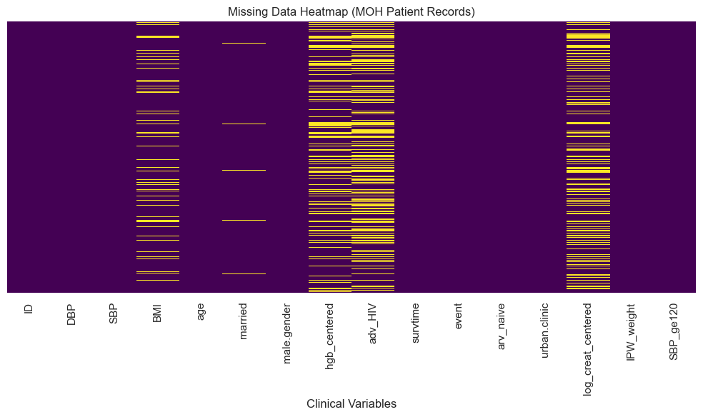

```python
plt.figure(figsize=(10, 6))
sns.heatmap(df.isnull(), cbar=False, cmap="viridis", yticklabels=False)
plt.title("Missing Data Heatmap (MOH Patient Records)", fontsize=12)
plt.xlabel("Clinical Variables")
plt.tight_layout()
plt.show()
```

### **2. DEEP DIVE: MISSINGNESS MECHANISMS**

#### **A. MCAR (Missing Completely At Random)**

- **Definition:** Missingness is independent of both observed and unobserved data.
- **Meaning:** The probability that a value is missing is unrelated to any characteristics of the patient or the study.
- **MOH Example:** A random power outage at a rural clinic causes the digital weighing scale to fail.
- **Result:** BMI measurements are missing for a random subset of patients.
- **Statistical Assessment:** Compare observed characteristics, such as **Age**, between patients with missing BMI and those with observed BMI.
- **Interpretation:** If there are no systematic differences between the two groups, the missingness may be consistent with MCAR.
- **Key Point:** MCAR is the **strongest and most restrictive** missing-data assumption.

```python
bmi_missing = df[df['BMI'].isnull()]['age'].dropna()
bmi_observed = df[df['BMI'].notna()]['age'].dropna()
t_stat, p_value = stats.ttest_ind(bmi_missing, bmi_observed)
```

> In this case, we compare the mean age of patients with missing BMI against the mean age of patients with observed BMI. This approach help assess whether BMI missingness is associated with an observed variable such as age.

```python
print(f"Result: T-test p-value for Age difference = {p_value:.4f}")
if p_value > 0.05:
    print("Conclusion: Fail to reject null hypothesis. BMI missingness may be MCAR.")
else:
    print("Conclusion: Significant difference. BMI missingness is likely NOT MCAR.")
```

```
Result: T-test p-value for Age difference = 0.3517
Conclusion: Fail to reject null hypothesis. BMI missingness may be MCAR.
```

#### **B. MAR (Missing At Random)**

- **Definition:** Missingness depends on **observed data**, but not on the missing value itself.
- **Meaning:** The probability that a value is missing is related to other information that has already been observed.
- **MOH Example:** Hemoglobin (**hgb_centered**) laboratory results are missing more frequently in **rural clinics** because they lack centrifuges.
- **Observed Factor:** Clinic location (e.g., **urban.clinic = 0** for rural clinics) explains the missingness.
- **Within Groups:** Among rural clinics, the missingness is assumed to be random after accounting for clinic location.
- **Statistical Assessment:** Compare the proportion of missing hemoglobin results across **urban and rural clinics**.
- **Interpretation:** If missingness is associated with observed factors such as clinic location, but not with the unobserved hemoglobin value itself after accounting for those factors, the data are consistent with MAR.
- **Key Point:** MAR is a common assumption underlying methods such as **multiple imputation**.

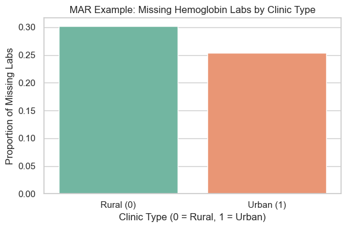

```python
df['hgb_missing_flag'] = df['hgb_centered'].isnull().astype(int)
plt.figure(figsize=(6, 4))
sns.barplot(x='urban.clinic', y='hgb_missing_flag', data=df, ci=None, palette="Set2")
plt.title("MAR Example: Missing Hemoglobin Labs by Clinic Type")
plt.ylabel("Proportion of Missing Labs")
plt.xlabel("Clinic Type (0 = Rural, 1 = Urban)")
plt.xticks(ticks=[0, 1], labels=["Rural (0)", "Urban (1)"])
plt.tight_layout()
plt.show()
```

### **Inferential Test**

#### **1. Chi-square test**

```python
from scipy.stats import chi2_contingency
# Create a contingency table
table = pd.crosstab(df['urban.clinic'], df['hgb_missing_flag'])

print(table)
```

```
hgb_missing_flag     0    1
urban.clinic
0                 1842  795
1                 1763  599
```

#### **Chi-square test**

```python
chi2, p_value, dof, expected = chi2_contingency(table)

print("Chi-square statistic:", chi2)
print("p-value:", p_value)
```

```
Chi-square statistic: 13.96717242781634
p-value: 0.0001860305748480715
```

### **2. What is being tested?**

The hypotheses are:

- **H₀:** Clinic type and hemoglobin missingness are independent.
- **H₁:** Clinic type and hemoglobin missingness are associated.

In other words, we are testing whether the **proportion of missing hemoglobin results differs between rural and urban clinics**.

### **3. Interpretation**

Using the conventional significance level of **5%**:

**If p < 0.05:**

> Reject H₀. There is a statistically significant association between clinic type and hemoglobin missingness. This provides evidence that missingness depends on an observed variable (clinic type), which is consistent with the MAR assumption.

**If p ≥ 0.05:**

> Fail to reject H₀. There is insufficient evidence of an association between clinic type and hemoglobin missingness.

### **Chi-Square Test of Association**

A **Chi-square test of independence** was conducted to determine whether hemoglobin missingness was associated with clinic type (rural versus urban).

- **Chi-square statistic:** χ² = 13.967
- **p-value:** p < 0.001
- **Significance level:** α = 0.05

Since the **p-value (0.000186) is less than 0.05**, the null hypothesis of independence is rejected.

**Interpretation:** There is a **statistically significant association between clinic type and missing hemoglobin laboratory results**. This indicates that the proportion of missing hemoglobin values differs between rural and urban clinics. Since clinic type is an observed variable, this finding provides **evidence consistent with the MAR (Missing At Random) mechanism**.

> **Report:** *A Chi-square test of independence showed a statistically significant association between clinic type and hemoglobin missingness, χ²(1) = 13.97, p < .001, suggesting that hemoglobin missingness depends on the observed clinic type, consistent with the MAR assumption.*

### **4. You can also report the proportions**

```python
proportions = df.groupby('urban.clinic')['hgb_missing_flag'].mean()
print(proportions)
```

```
urban.clinic
0    0.301479
1    0.253599
Name: hgb_missing_flag, dtype: float64
```

#### **Proportion of Missing Hemoglobin Results by Clinic Type**

The proportions of missing hemoglobin laboratory results were:

- **Rural clinics (urban.clinic = 0):** 0.301479 → **30.15%**
- **Urban clinics (urban.clinic = 1):** 0.253599 → **25.36%**

Thus, hemoglobin missingness was slightly higher in **rural clinics (30.15%)** compared with **urban clinics (25.36%)**.

### **Combined Interpretation**

A Chi-square test of independence showed a statistically significant association between clinic type and hemoglobin missingness, **χ²(1) = 13.97, p < .001**. The proportion of missing hemoglobin results was **30.15% in rural clinics** compared with **25.36% in urban clinics**. This indicates that hemoglobin missingness varies significantly by clinic type, providing evidence consistent with a **MAR (Missing At Random)** mechanism, since missingness is associated with an observed variable (clinic type).

### **5. If expected frequencies are small**

If some cells in the contingency table have small expected counts, use **Fisher's exact test** instead:

```python
from scipy.stats import fisher_exact
odds_ratio, p_value = fisher_exact(table)
print("Odds ratio:", odds_ratio)
print("p-value:", p_value)
```

```
Odds ratio: 0.7872216098203105
p-value: 0.00016998748688374594
```

#### **Fisher’s Exact Test**

A **Fisher’s exact test** was conducted to assess whether clinic type was associated with hemoglobin missingness.

- **Odds ratio:** OR = 0.787
- **p-value:** p < 0.001

Since the **p-value (0.000170) is less than 0.05**, the null hypothesis of independence is rejected.

**Interpretation:** There is a **statistically significant association between clinic type and hemoglobin missingness**. The odds ratio of **0.787** indicates that the odds of hemoglobin missingness differ between rural and urban clinics. This provides evidence that missingness is related to an **observed variable (clinic type)**, which is **consistent with the MAR mechanism**.

> **Report:** *Fisher’s exact test indicated a statistically significant association between clinic type and hemoglobin missingness (OR = 0.787, p < .001), suggesting that hemoglobin missingness depends on the observed clinic type, consistent with the MAR assumption.*

#### **C. MNAR (Missing Not At Random)**

- **Definition:** Missingness depends on the **unobserved (missing) value itself**.
- **Meaning:** The probability that a value is missing is related to the actual value that would have been observed.
- **MOH Example:** **Creatinine (`log_creat_centered`)** measurements are missing because patients with **severely failing kidneys** and therefore potentially very high creatinine levels were too critically ill to be transported to the central MOH laboratory.
- **Another Possible Reason:** Some critically ill patients may have **died before the creatinine measurement could be taken**.
- **Key Feature:** The missingness is related to the **unobserved creatinine level itself**, rather than only to observed characteristics such as age or clinic type.
- **Statistical Challenge:** MNAR **cannot be established or proven directly using the observed data alone**, because the values causing the missingness are themselves unobserved.
- **Assessment:** Establishing MNAR requires **clinical knowledge, domain expertise, sensitivity analysis, and assumptions about why the data are missing**.
- **Trainer Note:** A statistically non-significant association with observed variables does **not automatically prove MNAR**.
- **Key Point:** MNAR is the most difficult missing-data mechanism to identify because it depends on information that is **not observed**.

### **3. Treatment Strategies & Preventing Data Leakage**

#### **Critical Rule: Split Before Imputation**

- **Always split the dataset into training and testing sets before performing imputation.**
- The **training set** should be used to learn the imputation parameters.
- The **test set** should only be used to evaluate the final model.

#### **Why is this important?**

- If you impute missing values using the **entire dataset before splitting**, information from the test set can influence the training data.
- This is known as **data leakage**.
- Data leakage can make the model appear to perform better than it actually would on new, unseen data.
- It can lead to **overly optimistic estimates of model performance**.

#### **Correct Workflow**

1. **Load the data**
2. **Separate predictors (X) and outcome (y)**
3. **Split the data into training and testing sets**
4. **Fit the imputation method using only the training data**
5. **Apply the learned imputation parameters to both training and test data**
6. **Train the model using the imputed training data**
7. **Evaluate the model on the imputed test data**

#### **Example**

Suppose the training data contain:

- Mean age = **45 years**

and the test data contain:

- Mean age = **60 years**

If you calculate the overall mean before splitting, the test-set information contributes to the imputation value.

Instead:

> **Learn the mean = 45 from the training set → use 45 to impute missing values in both training and test sets.**

#### **Key Principle**

> **Never allow information from the test set to influence the training process.**

This applies not only to **imputation**, but also to:

- Standardization/scaling
- Feature selection
- Outlier treatment
- Encoding
- Dimensionality reduction
- Feature engineering
- Variable transformation

#### **Best Practice**

Use a **Pipeline** so that preprocessing and model training are performed correctly without accidentally causing data leakage.

**Remember:**

> **Split → Fit preprocessing on Train → Transform Train & Test → Train Model → Evaluate Test**

#### **Define Target and Features**

```python
target = 'SBP_ge120'
features = ['age', 'DBP', 'BMI', 'hgb_centered', 'log_creat_centered']

X = df[features]
y = df[target]
```

#### **Drop rows where the target itself is missing (if any)**

```python
mask = y.notna()
X = X[mask]
y = y[mask]
```

#### **TRAIN/TEST SPLIT (Stratified to maintain event rates)**

```python
X_train, X_test, y_train, y_test = train_test_split(
    X, y, test_size=0.3, random_state=42, stratify=y
)
```

#### **Strategy 1: Listwise Deletion (Complete Case Analysis)**

```python
X_train_del = X_train.dropna()
y_train_del = y_train[X_train_del.index]
X_test_del = X_test.dropna()
y_test_del = y_test[X_test_del.index]
```

#### **Strategy 2: Median Imputation (Robust to outliers)**

```python
imp_median = SimpleImputer(strategy='median')
X_train_med = pd.DataFrame(imp_median.fit_transform(X_train), columns=X.columns)
X_test_med = pd.DataFrame(imp_median.transform(X_test), columns=X.columns)
```

#### **Strategy 3: KNN Imputation (Uses similar patients to guess missing values)**

```python
imp_knn = KNNImputer(n_neighbors=5)
X_train_knn = pd.DataFrame(imp_knn.fit_transform(X_train), columns=X.columns)
X_test_knn = pd.DataFrame(imp_knn.transform(X_test), columns=X.columns)
```

#### **Strategy 4: MICE (Multivariate Imputation by Chained Equations)**

```python
imp_mice = IterativeImputer(max_iter=10, random_state=42)
X_train_mice = pd.DataFrame(imp_mice.fit_transform(X_train), columns=X.columns)
X_test_mice = pd.DataFrame(imp_mice.transform(X_test), columns=X.columns)
```

> **Imputation pipelines successfully fitted on Training Data and applied to Test Data.**

```python
datasets = {
    "1. Listwise Deletion": (X_train_del, y_train_del, X_test_del, y_test_del),
    "2. Median Imputation": (X_train_med, y_train, X_test_med, y_test),
    "3. KNN Imputation": (X_train_knn, y_train, X_test_knn, y_test),
    "4. MICE Imputation": (X_train_mice, y_train, X_test_mice, y_test)
}
datasets
```

[output not shown]

[output cut: 193 more lines]

```python
results = []

for name, (x_tr, y_tr, x_te, y_te) in datasets.items():
    if len(x_tr) == 0 or len(x_te) == 0:
        print(f"\n{name}: Skipped (Not enough data after deletion).")
        continue

    # Train Logistic Regression
    lr = LogisticRegression(max_iter=1000, random_state=42, penalty=None)
    lr.fit(x_tr, y_tr)

    # Predict
    preds = lr.predict(x_te)
    proba = lr.predict_proba(x_te)[:, 1]

    # Evaluate
    acc = accuracy_score(y_te, preds)
    auc = roc_auc_score(y_te, proba)

    print(f"\n--- {name} ---")
    print(f"Training N: {len(x_tr)} | Test N: {len(x_te)}")
    print(f"Accuracy: {acc:.4f} | AUC-ROC: {auc:.4f}")
    print(f"Coefficient for 'age': {lr.coef_[0][0]:.4f}")

    results.append({
        'Strategy': name,
        'Train_N': len(x_tr),
        'Test_N': len(x_te),
        'Accuracy': acc,
        'AUC': auc,
        'Age_Coef': lr.coef_[0][0]
    })
```

```
--- 1. Listwise Deletion ---
Training N: 2030 | Test N: 858
Accuracy: 0.9510 | AUC-ROC: 0.7516
Coefficient for 'age': 0.0610

--- 2. Median Imputation ---
Training N: 3499 | Test N: 1500
Accuracy: 0.9487 | AUC-ROC: 0.7664
Coefficient for 'age': 0.0582

--- 3. KNN Imputation ---
Training N: 3499 | Test N: 1500
Accuracy: 0.9493 | AUC-ROC: 0.7718
Coefficient for 'age': 0.0587

--- 4. MICE Imputation ---
Training N: 3499 | Test N: 1500
Accuracy: 0.9487 | AUC-ROC: 0.7686
Coefficient for 'age': 0.0591
```

```python
res_df = pd.DataFrame(results)
print("\n" + "="*75)
print(" SUMMARY TABLE: MODEL PERFORMANCE COMPARISON")
print("="*75)
print(res_df.to_string(index=False))
```

```
===========================================================================
 SUMMARY TABLE: MODEL PERFORMANCE COMPARISON
===========================================================================
            Strategy  Train_N  Test_N  Accuracy      AUC  Age_Coef
1. Listwise Deletion     2030     858  0.951049 0.751605  0.060978
2. Median Imputation     3499    1500  0.948667 0.766353  0.058202
   3. KNN Imputation     3499    1500  0.949333 0.771780  0.058743
  4. MICE Imputation     3499    1500  0.948667 0.768646  0.059081
```

Based on these results, **KNN Imputation is the best overall approach** if the primary goal is predictive performance.

#### **Model Performance Comparison**

| Strategy | Accuracy | AUC | Age Coef. |
| --- | --- | --- | --- |
| Listwise Deletion | 0.9510 | 0.7516 | 0.0610 |
| Median Imputation | 0.9487 | 0.7664 | 0.0582 |
| **KNN Imputation** | **0.9493** | **0.7718** | **0.0587** |
| MICE Imputation | 0.9487 | 0.7686 | 0.0591 |

#### **Important Point About Listwise Deletion**

Although listwise deletion has the **highest accuracy (95.10%)**, it has the **lowest AUC (0.7516)** and discards a substantial number of observations.

Therefore, I would **not select listwise deletion simply because its accuracy is highest**.

#### **Recommended Approach**

**KNN Imputation would be the preferred approach based on these results**, because it provides the highest AUC while retaining the full sample.

You could report it as:

> *Among the four missing-data treatment strategies, KNN imputation provided the best overall predictive performance, achieving the highest AUC (0.772) and a high classification accuracy (94.93%). Although listwise deletion yielded a marginally higher accuracy (95.10%), it resulted in substantial loss of observations and had the lowest AUC (0.752). Median and MICE imputation produced slightly lower AUC values of 0.766 and 0.769, respectively. Therefore, KNN imputation was selected as the preferred strategy because it retained the full sample while providing the strongest discriminatory performance.*

> **One caveat:** If the primary objective is **statistical inference rather than prediction**, the choice may be different. For inference, **MICE** is often preferable because it accounts for uncertainty introduced by missing-data imputation through multiple imputed datasets.

### **Trainer’s Conclusion & Best Practices**

#### **1. Deletion / Listwise Deletion**

- Appropriate mainly when the data are **MCAR (Missing Completely At Random)**.
- Works better when the dataset has a **large sample size**.
- Removing observations with missing values can substantially reduce the sample size.
- Loss of observations reduces **statistical power**.
- If the data are not MCAR, deletion can introduce **selection bias**.
- **Best practice:** Avoid deletion when a large proportion of observations would be lost or when the MCAR assumption is questionable.

#### **2. Mean/Median Imputation**

- **Mean or median imputation** is simple and computationally fast.
- Suitable for simple applications and exploratory analysis.
- However, it treats imputed values as if they were actually observed.
- Can artificially **reduce the variability** of the variable.
- May distort relationships and correlations between variables.
- Can result in **underestimated standard errors** and potentially misleading statistical inference.
- **Median imputation** is generally more robust than mean imputation when the variable is skewed or contains outliers.
- **Best practice:** Use with caution, particularly for formal statistical inference.

#### **3. KNN Imputation**

- **K-Nearest Neighbors (KNN)** uses information from similar observations to estimate missing values.
- Particularly useful when observations with similar characteristics are expected to have similar values.
- Can work well when **local patterns or neighborhoods** exist in the data.
- Can preserve relationships between variables better than simple mean/median imputation.
- Computationally more demanding than simple imputation methods.
- May become **computationally expensive for very large datasets**, such as national-level MOH databases.
- Requires appropriate **scaling of variables** because KNN relies on distances between observations.
- **Best practice:** Consider KNN when the dataset is moderate in size and meaningful similarity between patients can be established.

#### **4. MICE (Multiple Imputation by Chained Equations)**

- **MICE** creates multiple plausible versions of the dataset by estimating missing values based on other variables.
- Particularly appropriate when data are assumed to be **MAR (Missing At Random)**.
- Preserves relationships and correlations between variables better than simple imputation.
- For example, MICE can account for the relationship between **Age, Creatinine, Hemoglobin, and other clinical variables**.
- Produces multiple imputed datasets, allowing uncertainty due to missing data to be incorporated into statistical inference.
- Results from the multiple datasets are typically **pooled** to obtain final estimates.
- More computationally demanding than mean/median imputation.
- **Best practice:** MICE is often a strong choice for **clinical and epidemiological research involving MAR data**, especially when statistical inference is the primary objective.

#### **Overall Recommendation**

| Method | Main Advantage | Main Limitation | Best Use |
| --- | --- | --- | --- |
| **Deletion** | Simple | Loss of observations and potential bias | MCAR + large sample |
| **Mean/Median** | Fast and simple | Reduces variability | Simple exploratory analysis |
| **KNN** | Uses similar observations | Computationally expensive | Moderate-sized datasets |
| **MICE** | Preserves relationships and uncertainty | More complex | MAR clinical/epidemiological data |

#### **Key Takeaway**

> **There is no single imputation method that is universally best. The appropriate method depends on the missing-data mechanism, amount of missingness, research objective, and characteristics of the dataset.**

> For **prediction**, methods such as KNN may perform very well, as shown in your model comparison. For **statistical inference with MAR clinical data**, **MICE is generally a stronger choice** because it accounts for uncertainty associated with missing values.